# LGCA

Valerie Hofmann

18 1 2022

# Checking for Multivariate Normal Distribution before Starting the Latent Growth Curve Modelling

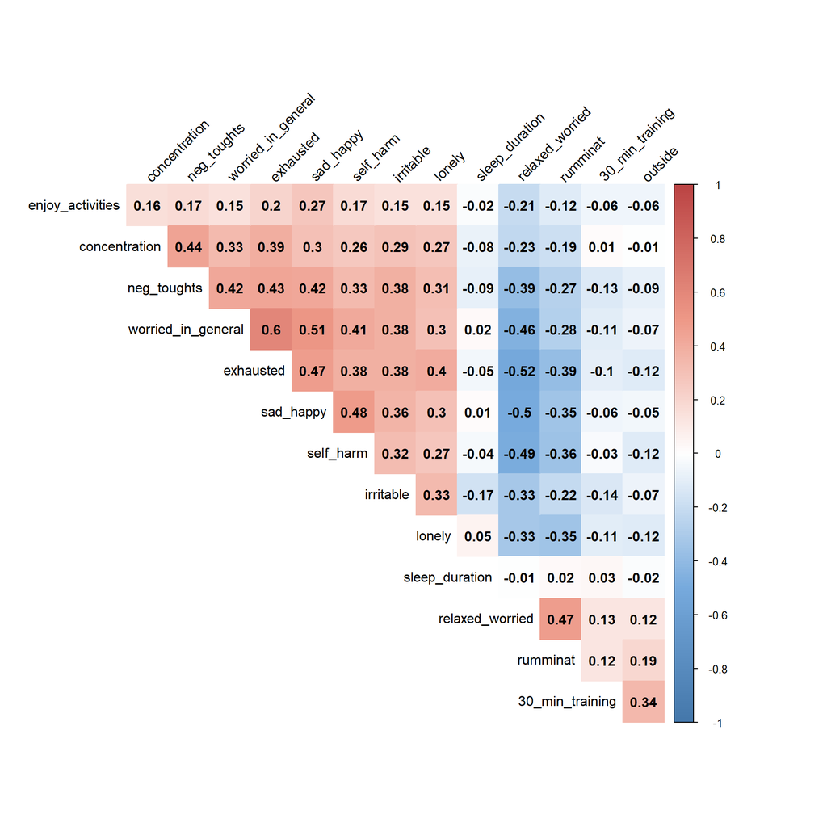

## Overview of Items and Scale (German Version)

The IMAGEN Team has create their own questionnaire based on Expert Ratings. **In the last two weeks**: 1. **EW2W1: worried_in_general** - …wie besorgt waren Sie im Allgemeinen? - Range: 0 = Überhaupt nicht, 4 = sehr 2. **EW2W2: sad_happy** - …wie glücklich oder traurig waren Sie? - Range: 0 = sehr trauig, 4 = sehr glücklich 3. **EW2W3 - enjoy_activities** - …wie sehr konnten Sie Ihre üblichen Aktivitäten genießen?, Range: 0 = Überhaupt nicht, 4 = sehr 4. **EW2W4 - relaxed_worried** - …wie entspannt oder ängstlich waren Sie? Range: 0 = sehr entspannt und ruigh, 4 = sehr nervös 5. **EW2W5 - rumminat** - …wie zappelig oder unruhig waren Sie? - Range: 0 = überhaupt nicht zappelig, 4 = sehr zappelig 6. **EW2W6 - exhausted** - …wie erschöpft oder müde waren Sie? - Range: 0 = überhaupt nicht erschöpft, 4 = sehr erschöpft 7. **EW2W7 - concentration** - …wie gut konnten Sie sich konzentrieren oder fokussieren? - Range: 0 = sehr fokussiert, 4 = sehr unfokussiert 8.**EW2W8 - irritable** - …wie irritierbar oder reizbar sind Sie gewesen? - Range: 0 = Überhaupt nicht, 4 = sehr 9. **EW2W9 - lonely** - …wie einsam waren Sie? - Range: 0 = Überhaupt nicht, 4 = sehr 10. **EW2W10 - neg_toughts** - …inwieweit haben Sie negative Gedanken gehabt und über unangenehme Erfahrungen oder Dinge nachgedacht, die Ihnen ein schlechtes Gefühl bereitet haben? - Range: 0 = Überhaupt nicht, 4 die meiste Zeit 11. **EW2W11 - self_harm** - …haben Sie absichtlich versucht sich selbst zu verletzen oder weh zu tun? - Range: 0 = überhaupt nicht, 4 = Die meiste Zeit

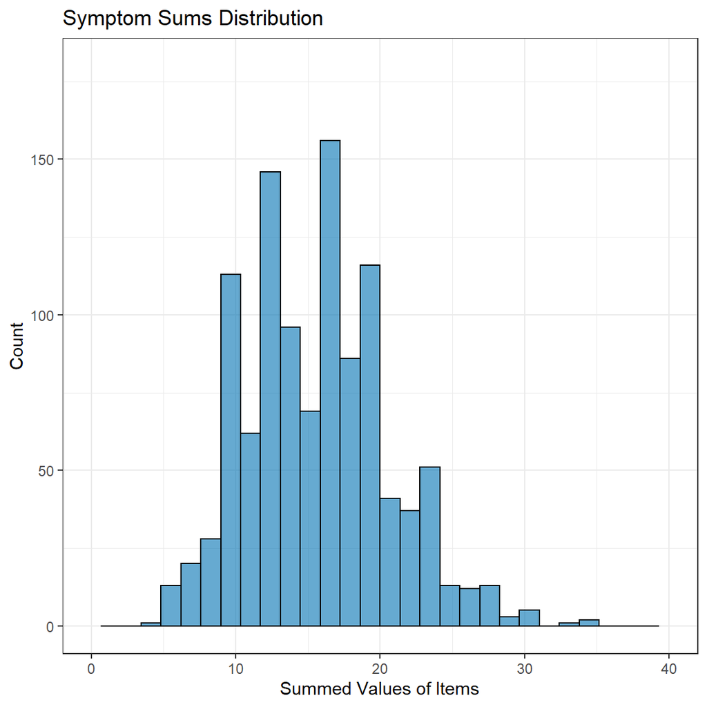

Shapiro-Wilk normality test

data: extra_long$Symptoms_SUM W = 0.98475, p-value = 3.184e-09

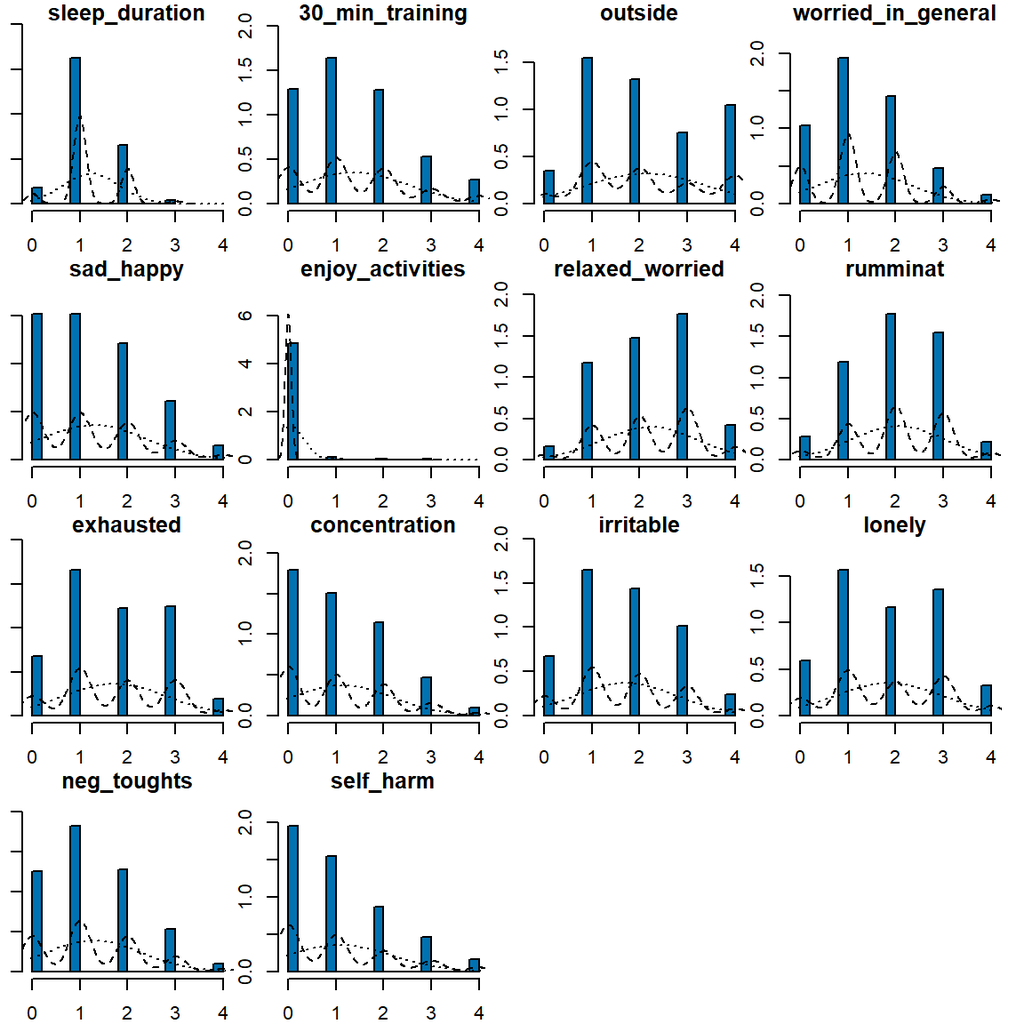

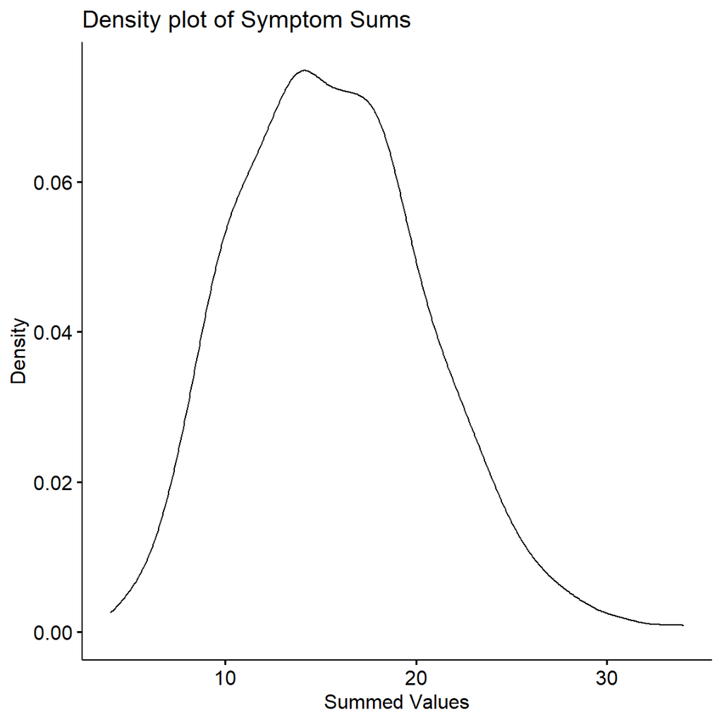

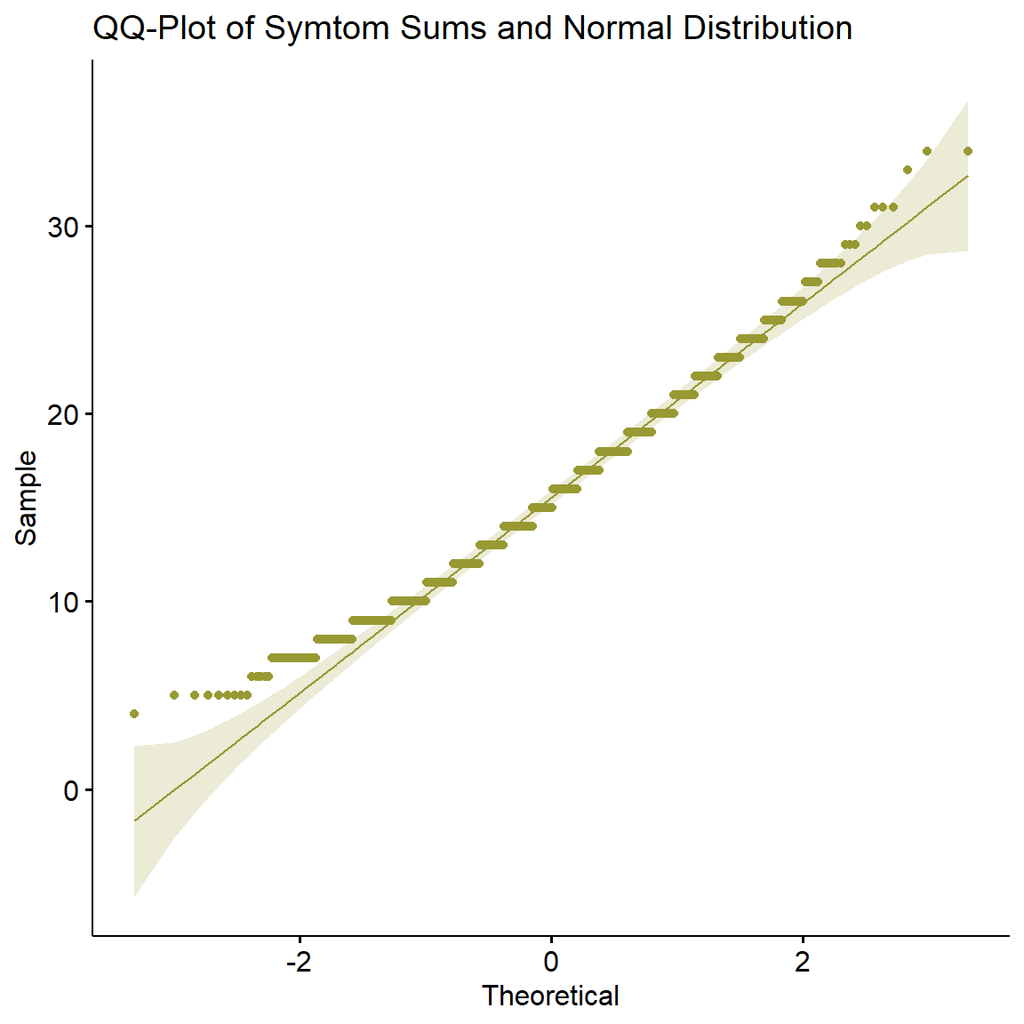

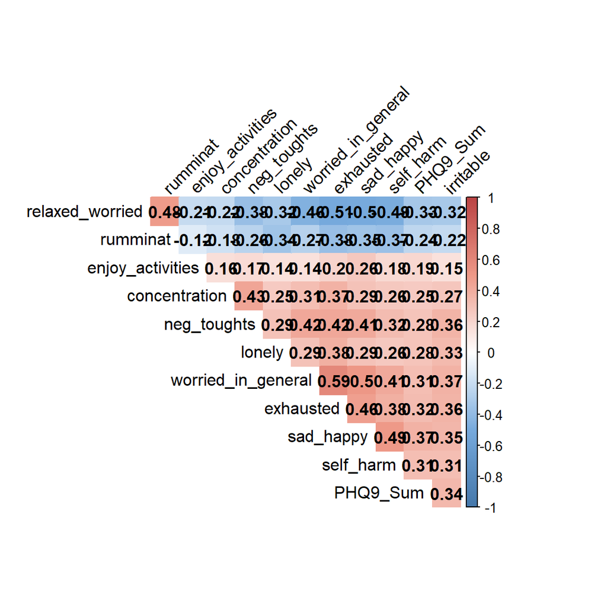